# PCA analysis of G4 IDS and CD data

Eric Largy

12/02/2021

```r
#setup----

#dvpt markdown necessary for theming
#remotes::install_github('rstudio/rmarkdown#1706')

##libs----
library("tidyverse")
library("readxl")
library("thematic")
# library('factoextra')
library('FactoMineR')
library('ggrepel')
library('ggiraph')
# library('showtext')

##auto theme----
thematic_rmd(
  bg = '#002B36', fg = '#EEE8D5', accent = 'auto',
  sequential = hcl.colors(n = 42, palette = 'viridis')
)

##operators----
`%notin%` <- Negate(`%in%`)
#data input----
```

# IDS and CD clustering

All data processed in R 4.0.1.

## Raw data processing

### UV

All UV spectra (including buffers) were gathered in a single dataframe, wherein a cation variable indicates whether any given spectrum was recorded in presence of absence of cation. The nature of the salt (potassium or sodium) used for each sample was extracted from the IDS table file and matched by oligonucleotide name.

Two buffers were recorded on different days for each two salts. For each sample, the matching blank (same salt, same day) was subtracted. The resulting spectra were baseline-subtracted by subtracting the average absorbance value at $\lambda > 320$ nm.

The data was finally normalized by convertion to molar extinction coefficients $\varepsilon$ in $M^{-1}cm^{-1}$, after extraction and matching of the corresponding concentrations C (converted to $M$ units) from the IDS table file, and assuming $l = 1$ cm:

$$\varepsilon = \frac{A}{l \times C}$$

```r
#oligo list----
seq.table <- readxl::read_excel("raw/IDS/UV.xlsx",
                                sheet = 'seq')

#UV files----

## UV with cation----
UV.input.cation <- readxl::read_excel("raw/IDS/UV.xlsx",
                                      sheet = 'cation') %>%
  add_column(cation = 'cation')

## UV without cation----
UV.input.no.cation <- readxl::read_excel("raw/IDS/UV.xlsx",
                                         sheet = 'no cation') %>%
  add_column(cation = 'no cation')

# processing----
UV <- UV.input.cation %>%
  pivot_longer(
    cols = 2:(ncol(UV.input.cation)-1),
    values_to = 'abs',
    names_to = 'oligo'
  ) %>%
  rbind(
    UV.input.no.cation %>%
      pivot_longer(
        cols = 2:(ncol(UV.input.no.cation)-1),
        values_to = 'abs',
        names_to = 'oligo'
      )
  ) %>%
  mutate(abs = as.numeric(abs)) %>%
  left_join(
    seq.table %>%
      select(oligo, salt, CF, oligo.number),
    by = 'oligo'
  ) %>%
  group_by(cation, wl) %>%
  mutate(
    abs.blk = if_else(
      salt == 'K',
      if_else(
        oligo.number < 19,
        abs - abs[oligo == 'buffer.K.1'],
        abs - abs[oligo == 'buffer.K.2']
      ),
      if_else(
        oligo.number < 19,
        abs - abs[oligo == 'buffer.Na.1'],
        abs - abs[oligo == 'buffer.Na.2']
      )
    )
  ) %>%
  group_by(oligo, cation, salt) %>%
  mutate(abs.cor = abs.blk - mean(abs.blk[wl > 320]),
         eps = abs.cor/(1*CF/1E6)) %>%
  ungroup() %>%
  filter(
    oligo %notin% c('buffer.K.1', 'buffer.K.2', 'buffer.Na.1', 'buffer.Na.2')
  )
```

### IDS

IDS were calculated for each oligonucleotide by subtraction of their processed ‘cation’ data from their ‘no cation’ data.

```r
#IDS----
IDS <- UV %>%
  group_by(oligo, wl) %>%
  mutate(delta.eps = eps[cation == 'no cation'] - eps[cation == 'cation']) %>%
  filter(cation == 'cation') %>%
  select(oligo, wl, delta.eps, salt)
```

### CD

The CD data (with buffers) was also collated into a single data table, and blank subtracted and baseline-corrected similarly to the UV data.

The ellipticities $\theta$ in mdeg were then normalized to molar ellipticities $\Delta \varepsilon$ in $M^{-1}cm^{-1}$, after extraction and matching of the corresponding concentrations C (converted to $M$ units) from the IDS table file, using:

$$\Delta \varepsilon = \frac{\theta}{32980 \times l \times C}$$

```r
#file import----
##CD input file reader----

CD_reader <- function(oligo.name){
  input.data <- read_delim(paste0("raw/CD/CD-",oligo.name,".txt"),
                           "\t", escape_double = FALSE, col_names = FALSE,
                           trim_ws = TRUE) %>%
    select(c(1,2))  %>%
    magrittr::set_colnames(c('wl', oligo.name))
}

##initialization----

###read one file to get wavelength column length and content
dummy <- CD_reader(oligo.name = "1XAV")

###initialize loop result data frame
cd.binder <- data.frame(dummy[,1])

####prepare list of files to import
sample.list <- c(seq.table$oligo, "buffer.K.1", "buffer.K.2", "buffer.Na.1", "buffer.Na.2")

##loop----

###import new data in a new column
for (i in sample.list) {

  buf <- CD_reader(oligo.name = i)

  cd.binder <- cbind(cd.binder, buf[,2])
}

#processing----

cd <- cd.binder %>%
  pivot_longer(
    cols = 2:(length(sample.list)+1),
    names_to = 'oligo',
    values_to = 'cd'
  ) %>%
  left_join(
    seq.table %>%
      select(oligo, salt, CF, oligo.number),
    by = 'oligo'
  ) %>%
  group_by(wl) %>%
  mutate(
    cd.blk = if_else(
      salt == 'K',
      if_else(
        oligo.number < 19,
        cd - cd[oligo == 'buffer.K.1'],
        cd - cd[oligo == 'buffer.K.2']
      ),
      if_else(
        oligo.number < 19,
        cd - cd[oligo == 'buffer.Na.1'],
        cd - cd[oligo == 'buffer.Na.2']
      )
    )
  ) %>%
  group_by(oligo, salt) %>%
  mutate(cd.cor = cd.blk - mean(cd.blk[wl > 320]),
         delta.eps = cd.cor/(32980*CF/1E6)) %>%
  ungroup() %>%
  filter(
    oligo %notin% c('buffer.K.1', 'buffer.K.2', 'buffer.Na.1', 'buffer.Na.2')
  ) %>%
  select(oligo, wl, delta.eps, salt)
```

## Processed data tables

### UV

```r
UV
```

| wl | cation | oligo | abs | salt | CF | oligo.number | abs.blk | abs.cor | eps |
| --- | --- | --- | --- | --- | --- | --- | --- | --- | --- |
| 220 | cation | 6AC7 | 0.810386 | K | 4.629630 | 1 | 0.551639 | 5.637484e-01 | 1.217696e+05 |
| 220 | cation | 2GKU | 0.768629 | K | 4.093328 | 2 | 0.509882 | 5.184640e-01 | 1.266608e+05 |
| 220 | cation | Hivpro3 | 0.775949 | K | 4.655493 | 3 | 0.517202 | 5.264432e-01 | 1.130800e+05 |
| 220 | cation | 2JSL | 0.848621 | K | 3.951008 | 4 | 0.589874 | 5.840281e-01 | 1.478175e+05 |
| 220 | cation | 186D | 0.842649 | Na | 4.366812 | 5 | 0.509035 | 5.986820e-01 | 1.370982e+05 |
| 220 | cation | 2MFT | 0.744483 | Na | 5.068424 | 6 | 0.410869 | 5.043526e-01 | 9.950876e+04 |
| 220 | cation | 2O3M | 0.771925 | K | 4.411116 | 7 | 0.513178 | 4.915570e-01 | 1.114360e+05 |
| 220 | cation | 2xBlock2_T258-A | 0.813326 | K | 3.803728 | 8 | 0.554579 | 5.631643e-01 | 1.480559e+05 |
| 220 | cation | 1XAV | 0.763479 | K | 4.372540 | 9 | 0.504732 | 5.244536e-01 | 1.199425e+05 |
| 220 | cation | 2LPW | 0.721669 | K | 3.772161 | 10 | 0.462922 | 4.868420e-01 | 1.290618e+05 |

[output cut: 6278 more lines]

### CD

```r
cd
```

| oligo | wl | delta.eps | salt |
| --- | --- | --- | --- |
| 6AC7 | 335.0 | -6.502857e-01 | K |
| 2GKU | 335.0 | -1.318459e+00 | K |
| Hivpro3 | 335.0 | -1.310792e-01 | K |
| 2JSL | 335.0 | 2.568809e-01 | K |
| 186D | 335.0 | -5.274152e-01 | Na |
| 2MFT | 335.0 | -2.602489e-01 | Na |
| 2O3M | 335.0 | -1.006267e+00 | K |
| 2xBlock2_T258-A | 335.0 | -1.898359e-01 | K |
| 1XAV | 335.0 | -1.026155e+00 | K |
| 2LPW | 335.0 | -1.352144e+00 | K |

[output cut: 5534 more lines]

### IDS

```r
IDS
```

| oligo | wl | delta.eps | salt |
| --- | --- | --- | --- |
| 6AC7 | 220 | -5.828854e+03 | K |
| 2GKU | 220 | -3.550453e+03 | K |
| Hivpro3 | 220 | -8.484464e+03 | K |
| 2JSL | 220 | -1.069642e+04 | K |
| 186D | 220 | -4.788024e+03 | Na |
| 2MFT | 220 | 2.994843e+03 | Na |
| 2O3M | 220 | -8.593101e+03 | K |
| 2xBlock2_T258-A | 220 | -2.461973e+04 | K |
| 1XAV | 220 | -8.143839e+03 | K |
| 2LPW | 220 | -1.038353e+03 | K |

[output cut: 3134 more lines]

## Processed data plots

### UV

Visually, some oligonucleotides seem to have fairly superimposed spectra, which is not boding well for IDSs, i.e. 5YEY, DT2-L2T4, Ran4, and 2LXQ. Otherwise, it looks ok.

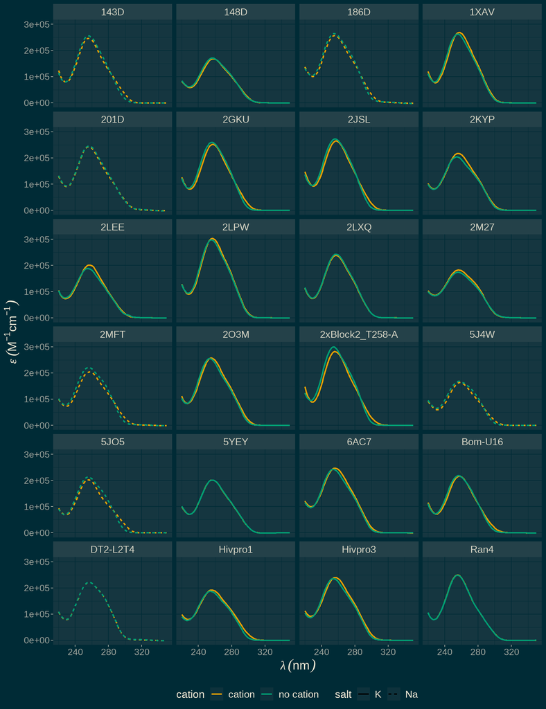

UV spectra in presence or absence of cation. Spectra acquired in presence of sodium are dashed.

```r
#data plot----

## UV----

p.UV <- UV %>%
  ggplot(
    aes(
      x = wl, y = eps,
      color = cation,
      group = cation,
      linetype = salt
    )
  ) +
  geom_line(
    size = 1,
    show.legend = T
  ) +
  facet_wrap(~oligo,
             ncol = 4) +
  labs(
    x = bquote(lambda~(nm)),
    y = bquote(epsilon~(M^-1*cm^-1))
  ) +
  theme(
    axis.title = element_text(size = 16),
    axis.text = element_text(size = 12),
    strip.text = element_text(size = 13),
    legend.position = 'bottom',
    legend.text = element_text(size = 13),
    legend.title = element_text(size = 14)
  )

p.UV
```

### IDS

Most IDS signature look fine, with the infamous negative band at 295 nm. As expected from the UV spectra, 5YEY, DT2-L2T4, Ran4, and 2LXQ are pretty flat. 2M27 is not looking good either.

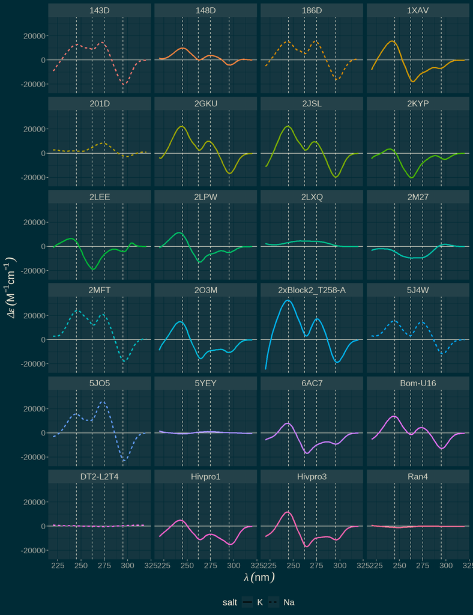

IDS signature of the panel. IDS determined from sodium-containing solutions are dashed. The vertical lines are placed at 245, 262, 275, and 295 nm.

```r
##IDS----

p.IDS <- IDS %>%
  filter(wl <= 320) %>%
  ggplot(
    aes(
      x = wl, y = delta.eps,
      color = oligo,
      group = oligo,
      linetype = salt
    )
  ) +
  geom_vline(
    xintercept = 295,
    linetype = 'dashed'
  ) +
  geom_vline(
    xintercept = 275,
    linetype = 'dashed'
  ) +
  geom_vline(
    xintercept = 262,
    linetype = 'dashed'
  ) +
  geom_vline(
    xintercept = 245,
    linetype = 'dashed'
  ) +
  geom_hline(
    yintercept = 0
  ) +
  geom_line(
    size = 1,
    show.legend = TRUE
  ) +
  guides(
    color = 'none'
  ) +
  facet_wrap(~oligo,
             ncol = 4) +
  labs(
    x = bquote(lambda~(nm)),
    y = bquote(Delta*epsilon~(M^-1*cm^-1))
  ) +
  theme(
    axis.title = element_text(size = 16),
    axis.text = element_text(size = 12),
    strip.text = element_text(size = 13),
    legend.position = 'bottom',
    legend.text = element_text(size = 13),
    legend.title = element_text(size = 14)
  )

p.IDS
```

### CD

All spectra look to have been correctly acquired and processed. 2xBlock2_T258-A and, to a lower extent, DT2-L2T4 have ‘weird’ signatures. The former has a negative band at 260 nm, and the latter seems to be polymorphic.

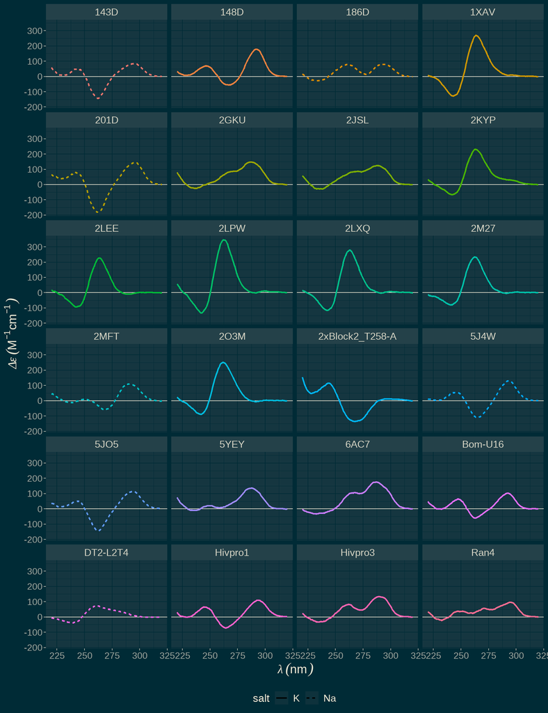

CD spectra of the panel. The spectra are dashed when acquired in sodium-containing solutions.

```r
##CD----

p.cd <- cd %>%
  filter(wl <= 320) %>%
  ggplot(
    aes(
      x = wl, y = delta.eps,
      color = oligo,
      group = oligo,
      linetype = salt
    )
  ) +
  geom_hline(
    yintercept = 0
  ) +
  geom_line(
    size = 1,
    show.legend = TRUE
  ) +
  facet_wrap(~oligo,
             ncol = 4) +
  labs(
    x = bquote(lambda~(nm)),
    y = bquote(Delta*epsilon~(M^-1*cm^-1))
  ) +
  guides(
    color = 'none'
  ) +
  theme(
    axis.title = element_text(size = 16),
    axis.text = element_text(size = 12),
    strip.text = element_text(size = 13),
    legend.position = 'bottom',
    legend.text = element_text(size = 13),
    legend.title = element_text(size = 14)
  )

p.cd
```

## PCA and clustering

### Data preparation

Before starting the PCA, I have manually attributed a topology to each sequence based on my personal interpretation of the CD (I haven’t looked up the sequence online, although I know some by heart). This is what will be called *human topology* after.

```r
## human interpretation of CD for reference----

human.topo <- data.frame(
  oligo = seq.table$oligo,
  topo = c('hybrid', 'hybrid', 'hybrid', 'hybrid', 'hybrid', 'antiparallel',
           'parallel', 'weird', 'parallel', 'parallel', 'parallel', 'parallel',
           'parallel', 'parallel', 'weird', 'antiparallel', 'hybrid', 'antiparallel',
           'antiparallel', 'antiparallel', 'antiparallel', 'antiparallel', 'antiparallel', 'antiparallel')
)

human.topo %>%
  magrittr::set_colnames(c('oligonucleotide', 'topology'))
```

| oligonucleotide | topology |
| --- | --- |
| 6AC7 | hybrid |
| 2GKU | hybrid |
| Hivpro3 | hybrid |
| 2JSL | hybrid |
| 186D | hybrid |
| 2MFT | antiparallel |
| 2O3M | parallel |
| 2xBlock2_T258-A | weird |
| 1XAV | parallel |
| 2LPW | parallel |

[output cut: 14 more lines]

The PCA was performed on the CD data, or IDS data, or both collated. In the latter case, to avoid a quantitative bias from one technique over another, the number of data points was made identical by i) rescaling the x-axis between 220 and 320 nm, and ii) removing non-integer wavelength from the CD data (the step was set at 0.5 nm vs 1.0 nm for UV; ideally they should have been equal).

In any case, the data was switched from long to large format ([explanations](https://en.wikipedia.org/wiki/Wide_and_narrow_data)).

```r
## training set----
training.ids <- IDS %>%
  filter(wl <= 320) %>% #IMPORTANT: CHANGES RESULTS
  mutate(wl = paste0("ids-", wl)) %>%
  pivot_wider(
    names_from = wl,
    values_from = delta.eps
  )

# ncol(training.ids)

training.cd <- cd %>%
  filter(wl <= 320) %>% #IMPORTANT: CHANGES RESULTS
  filter(wl%%1 == 0) %>% #removing non integer wl to have the same number of data points than in IDS
  mutate(wl = paste0("cd-", wl)) %>%
  pivot_wider(
    names_from = wl,
    values_from = delta.eps
  )
```

### PCA on CD data

#### Parameters and quality of PCA

The PCA was performed with centering but no scaling (the data is already normalized), using the `prcomp` package. The coordinates of the first five dimensions were kept for k-means clustering (set manually to four clusters, i.e. one per basic topology and keeping an extra one for weird stuff).

The Scree plot shows the proportion of the variance that can be attributed to a principal component. Here, more than 90% of the variance can be attributed to the first two principal components. The factor maps shows that almost all wavelengths are well described by the first two principal components (the sum of their square cosine is close to 1). The variables more poorly described by the first two principal components are the wavelengths around 220–230 nm and above 300 nm, which are typically not used to infer topologies. A few wavelengths around 250 nm are also not perfectly described, having a significant contribution of the third principal component.

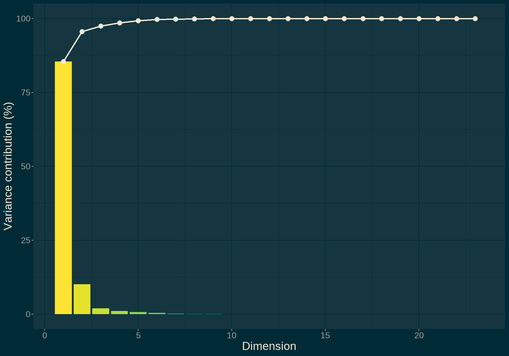

Scree plot, showing the contribution of principal components to the total variance (bars), and the corresponding cumulative variance (points and line).

```r
pca.scree
```

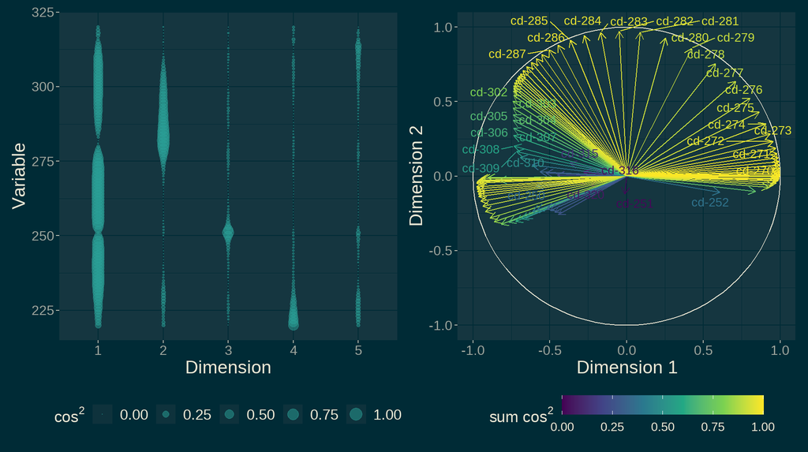

Left: Factor map of the square cosine of the variables for the first five components (larger points show a better representation quality). Right: Circle of correlation for the first two principal components. Variables close to the circle and with larger sum of square cosine are best described by these principal components

```r
patchwork::wrap_plots(pca.fac.map + pca.var.cor)
```

#### PCA results

The results are shown as coordinates in the first two dimensions, colored by k-means cluster, and shaped by ‘human topology’. The contributions of the variables are shown below. As expected, the band at 290 nm is found in antiparallel G4s, the band at 260 nm in parallel G4s, and the hybrid G4s are in between with contributions at 290 nm and 275 nm. The weird 2xBlock2_T258-A is completely isolated (cluster of one), which is satisfying given its unique CD signature. DT2-L2T4 is clusterd with the hybrid G4s, as could be expected, yet it is on the outskirt of the cluster because of its seemingly non-pure signature (large 260 nm contribution).

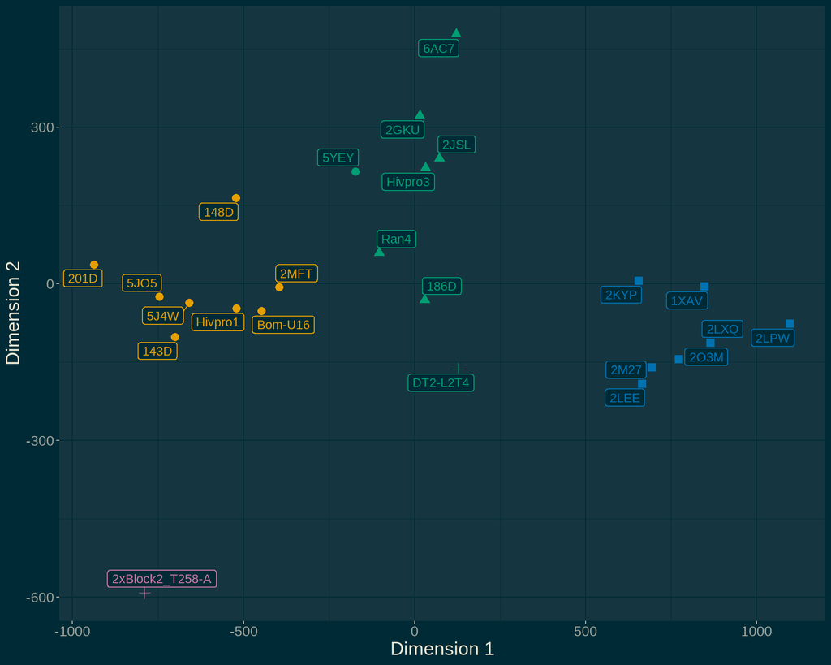

```r
pca.coord
```

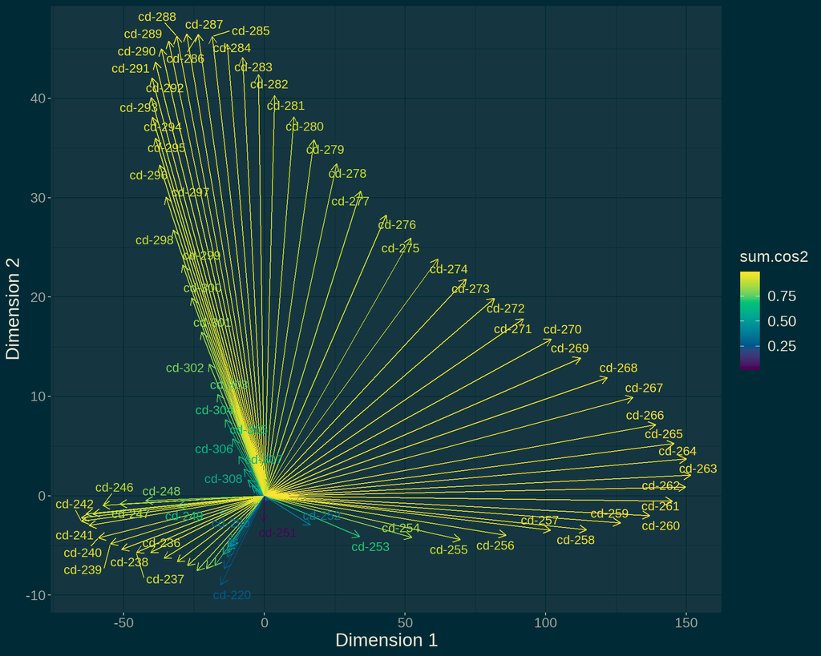

```r
pca.var.coord
```